# Baseball!

This project seeks to explore whether the [Relative Age Effect (RAE)](https://en.wikipedia.org/wiki/Relative_age_effect) is present in major league baseball. We will examine the relationship (if any) between the month of year a player is born and their success as a baseball player.

Success as a baseball player will be measured through three different criteria:

- Salary
- Batting Average (Hits / At Bats)
- Earned Run Average (Earned Runs allowed per game (27 outs))

Data used is from [SeanLahman's Baseball Archive](http://www.seanlahman.com/baseball-archive/statistics/) and includes playing statistics through the end of the 2016 season. Although there are advanced statistics that may better represent a player's proficiency, they are not included in this dataset and so are excluded.

# Data Import and Functions

```python
'''
Import libraries and data
Master.csv includes player birthdays
batting, pitching and salaries include stats for batting average, ERA and salary, respectively
'''

import matplotlib.pyplot as plt
import numpy as np
import pandas as pd
import seaborn as sns

master_import = pd.read_csv('Master.csv')
batting_import = pd.read_csv('Batting.csv')
pitching_import = pd.read_csv('Pitching.csv')
salaries_import = pd.read_csv('Salaries.csv')
```

```python
'''
remove rows from dataframe where player did not have relevant stats recorded
used when preparing to plot specific stats
'''

def trim(df, column):
    trimmed_df = df[df[column] > 0]
    return trimmed_df
```

```python
'''
group data by month and the corresponding mean
of the specified stat for all players born in that month
also return the mean of that stat for all players
'''

def plot_by_month_mean(df, column):
    groupby = df.groupby('birthMonth')[column].mean()
    mean = groupby.mean()
    groupby = groupby.rename(index={1: 'January', 2: 'February', 3: 'March', 4: 'April',
                                         5: 'May', 6: 'June', 7: 'July', 8: 'August', 9: 'September',
                                         10: 'October', 11: 'November', 12: 'December'})
    return groupby, mean
```

```python
'''
group data by month and the corresponding size
of the specified stat for all players born in that month
also return the mean of that stat for all players
'''

def plot_by_month_size(df, column):
    groupby = df.groupby('birthMonth')[column].size()
    mean = groupby.mean()
    groupby = groupby.rename(index={1: 'January', 2: 'February', 3: 'March', 4: 'April',
                                         5: 'May', 6: 'June', 7: 'July', 8: 'August', 9: 'September',
                                         10: 'October', 11: 'November', 12: 'December'})
    return groupby, mean
```

```python
'''
Plot bar-graph and describe data:
data = dataframe to plot
mean = value where horizontal line will be plotted; should be mean of all players
anno_x and _y = where to plot the annotation for the horizontal line
ymin and ymax = enter a value to modify range on y axis
ylabel = label the y-axis
title = give the graph a title
'''

def bar_graph(data, mean, anno_x, anno_y, ymin, ymax, ylabel, title):
    bar = data.plot(kind='bar'); plt.axhline(mean, color='b')
    bar.annotate('Overall Mean', xy=(anno_x, anno_y))
    bar.set_ylim(ymin, ymax)
    plt.xlabel('Birth Month')
    plt.ylabel(ylabel)
    plt.title(title)
    print data.describe()
    plt.show()
```

```python
'''
Plot the distribution for data. Draws a histogram and fits a kernal density estimate.
Specify data variable and enter a number 'b' for total bins.
'''
def distribution(data, b):
    sns.distplot(data, bins=b)
    plt.show()
    print data.describe()
```

# Data Wrangling

In order to analyze the data, we need to organize it first. The following code calculates career statistics for us and saves them into dataframes. For both batting and pitching stats, an arbitrary cut-off needed to be set in order to avoid situations where a player finished their season hitting 1.000 due to a single lucky at bat, or a pitcher who had an infinitely large ERA because they failed to record an out.

Most major league records require a minimum of 60 games be played before a player's stats are eligible for consideration. The requirements for this project are in the same spirit but less stringent: for batters, they must have appeared at the plate at least 60 times in a season for their average to be included. Pitchers needed to record at least 60 outs for inclusion in the data. These number eliminated the outliers without whittling the players too much. Unlike major league records which seek only to track the best, because we want to evaluate players both above and below average we're interested more in including as many players as possible.

Note that salary data was not included for years preceding 1985. All players with data included, regardless of playing time, are included. The minimum amount a player earned during their career was \$60,000; to make plotting salaries easier they have all been divided by 10,000. The most a player earned over their career is \$398,416,252. I thought this was a mistake at first, but then I looked up Alex Rodriguez (b. July). [Wow](http://time.com/4450818/alex-rodriguez-yankees-salary/). These numbers aren't even adjusted for inflation.

```python
'''
Create dataframe 'df_avg' for career Batting Average
Stats are not counted if player did not participate in at least 60 at bats that season
Batting average calculated by dividing total hits and total at bats
'''

batting_import = batting_import[batting_import['AB'] >= 60]
batting = batting_import.groupby('playerID').sum()
batting['AVG'] = batting['H']/(batting['AB'])
avg = batting['AVG']
df_avg = pd.DataFrame(avg, columns=['AVG'])
```

Let's take a look at the distribution of batting averages. We would expect this to have a normal distribution with the bulk of batters being about average (around .250), with poor batters trending toward .200 (and lower) and the exceptional batters flirting with .300.

Observing the chart below we can see this is correct. As expected, the majority of hitters are average. Additionally, the distributino is left-skewed demonstrating that good hitters are harder to find than bad hitters!

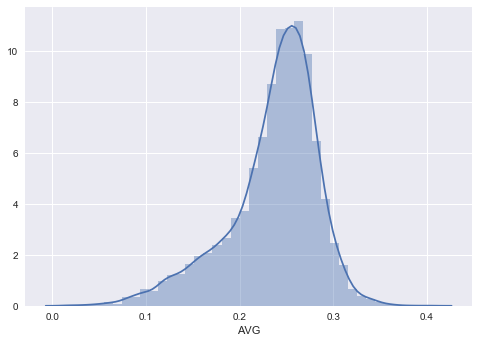

```
count    8674.000000
mean        0.235840
std         0.048281
min         0.016393
25%         0.214286
50%         0.245434
75%         0.267868
max         0.402985
Name: AVG, dtype: float64
```

```python
# Distribution of batting averages

distribution(avg, 40)
```

```python
'''
Create dataframe 'df_era' for career ERA
Stats are not counted if player did not record at least 60 outs in that season
ERA calculated by comparing total allowed ERs to total outs (divided by 27, as 3 outs/inning and 9 innings/game)
'''

pitching_import = pitching_import[pitching_import['IPouts'] >= 60]
pitching = pitching_import.groupby('playerID').sum()
pitching['careerERA'] = pitching['ER']/(pitching['IPouts']/27)
era = pitching['careerERA']
df_era = pd.DataFrame(era, columns=['careerERA'])
```

Just as with batters, we should expect to see a normal curve with pitcher ERA. Because a low ERA is desired, we might anticipate to a right-skewed distribution.

The chart below confirms these expectations.

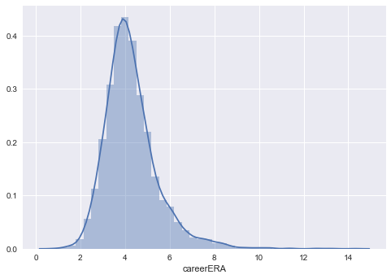

```
count    6486.000000
mean        4.269754
std         1.199872
min         0.782609
25%         3.510000
50%         4.093402
75%         4.807862
max        14.318182
Name: careerERA, dtype: float64
```

```python
# Distribution of ERAs

distribution(era, 40)
```

```python
'''
Create dataframe 'df_salaries'
salary is sum of monies earned over entire career
minimum salary earned is $60,000; dividing by 10,000 for brevity
NOTE: data unavailable before 1985
'''
salaries = salaries_import.groupby('playerID').sum()
salaries['salary'] = salaries['salary']/10000
df_salaries = pd.DataFrame(salaries, columns=['salary'])
```

We might expect to see a right-skewed salary distribution. The majority of players probably are not multi-millionaires, but the few superstars with 9-digit contracts will skew the data. Additionally, salaries have been increasing over time. Players from the 80s and 90s may not have made in their career what players today my make in a season.

Observing the below chart we can confirm this. In fact, the outliers are so extreme the graph is not very meaningful. To help illustrate the outliers influence, we can compare the group's average salary (\$10,692,364) to its median salary (\$1,534,900) -- over a \$9 million difference!

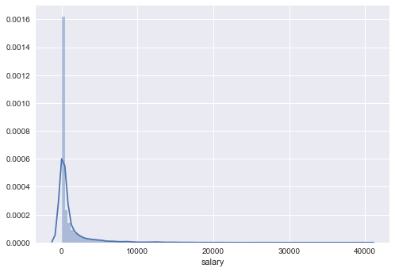

```
count     5155.000000
mean      1069.236407
std       2406.133457
min          6.000000
25%         49.525000
50%        153.490000
75%        896.446650
max      39841.625200
Name: salary, dtype: float64
```

```
153.49
```

```python
# Salary distribution

distribution(salaries['salary'], 100)
salaries['salary'].median()
```

Even if we remove the 100 highest paid players the graph is still heavily skewed. What a bunch of paupers!

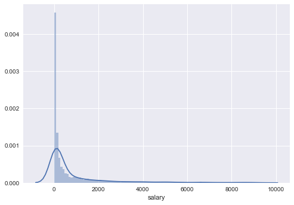

```
count    5055.000000
mean      820.056196
std      1540.576926
min         6.000000
25%        49.035000
50%       147.500100
75%       788.787850
max      9234.016600
Name: salary, dtype: float64
```

```python
'''
Sort salaries and then plot, removing the 100 highest earners.
List turned into dataframe to allow
'''

salaries_sorted = salaries['salary'].sort_values()
distribution(salaries_sorted[:-100], 100)
```

```python
'''
Create dataframe 'df_master' for player's birth month
'''
master = master_import.groupby('playerID').sum()['birthMonth']
df_master = pd.DataFrame(master, columns=['birthMonth'])
```

# Data Exploration

We've isolated the important stats for each category and observed that their distributions make logical sense. Let's now start to explore our initial question of whether the Relative Age Effect (RAE) is present in MLB players. We'll begin by exploring the first requirement to being a successful baseball players: Making it to the big leagues.

When we plot the distribution of players born each month, if we expect the RAE to have any significant bearing we should anticipate that some months will have significantly more players than others.

```
count      12.000000
mean     1566.916667
std       138.929975
min      1366.000000
25%      1449.750000
50%      1547.000000
75%      1638.500000
max      1831.000000
Name: birthMonth, dtype: float64
```

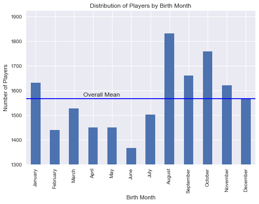

```python
'''
Plot the distribution of players by birthMonth using a bar graph
'''

sum_by_month, sum_mean = plot_by_month_size(df_master, 'birthMonth')

bar_graph(sum_by_month, sum_mean, 2.5, 1575, 1300, None, 'Number of Players', 'Distribution of Players by Birth Month')
```

Our dataset shows that between 1366 (June) and 1831 (August) players were born during each month (on average 1567 players per month). An initial glance at the distribution may lead one to draw conclusions: August-born babies having a better chance of making the big leagues! Late-Summer to Early-Winter babies are better than Spring babies! Maybe there is something to the RAE!

However, before we get too far ahead of ourselves, it is important to recognize that the general population is not uniformly distributed. In fact, according to the [CDC](https://www.cdc.gov/nchs/nvss/births.htm), August is regularly the month in which most babies are born. Consequently, it's likely not that a specific birth month provides inherent advantages to aspiring ball players but rather there are simply more babies born in that months than others, and thus a larger population to draw players from. A deeper statistical analysis (beyond the scope of this project) would be necessary to determine if these findings hold any significance.

The above dataframes are all organized with the playerID as their index and their respective variable (AVG, ERA, salary, birthMonth) as the column. We'll create one more dataframe that combines them all together.

Let's do a little more quick clean up. We'll combine all the above dataframes into a single one and then, we'll prepare dataframes to explore the individual statistics compared to birthMonth.

```python
# Combine the above dataframes into a single dataframe

df = pd.concat([df_avg, df_era, df_salaries, df_master], join='outer', axis=1)
```

```python
# Remove zero values for individual stats

df_avg = trim(df, 'AVG')
df_era = trim(df, 'careerERA')
df_salary = trim(df, 'salary')
```

# Statistics by Month

```
count    12.000000
mean      0.235946
std       0.001364
min       0.233251
25%       0.235007
50%       0.236157
75%       0.237034
max       0.237538
Name: AVG, dtype: float64
```

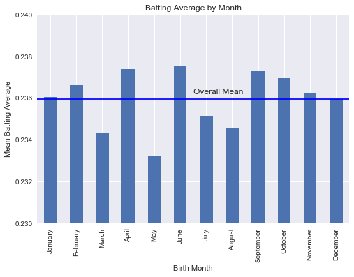

```python
# Examine batting averages

avg_by_month, avg_mean = plot_by_month_mean(df_avg, 'AVG')
bar_graph(avg_by_month, avg_mean, 5.5, .2362, .23, .24, 'Mean Batting Average', 'Batting Average by Month')
```

```
count    12.000000
mean      4.268117
std       0.048251
min       4.195500
25%       4.220103
50%       4.275692
75%       4.298577
max       4.339344
Name: careerERA, dtype: float64
```

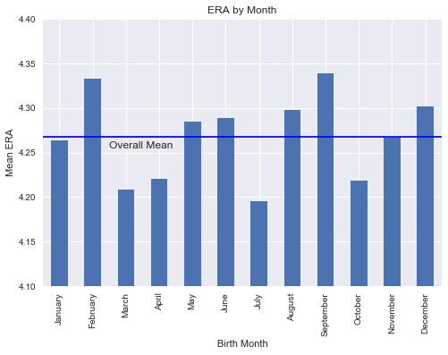

```python
# Examine ERAs

era_by_month, era_mean = plot_by_month_mean(df_era, 'careerERA')
bar_graph(era_by_month, era_mean, 1.5, 4.255, 4.1, 4.4, 'Mean ERA', 'ERA by Month')
```

```
count      12.000000
mean     1073.914046
std       129.106768
min       879.278962
25%       971.403213
50%      1086.400960
75%      1173.796682
max      1265.783715
Name: salary, dtype: float64
```

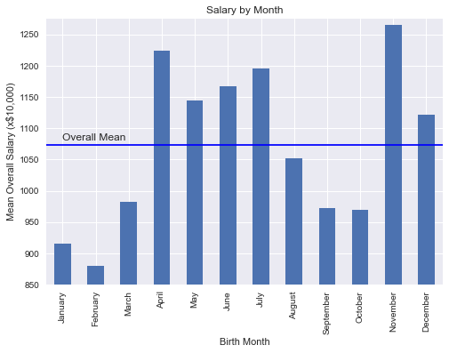

```python
# Examine salaries

salary_by_month, salary_mean = plot_by_month_mean(df_salary, 'salary')
bar_graph(salary_by_month, salary_mean, 0, 1080, 850, 1275, 'Mean Overall Salary (x$10,000)', 'Salary by Month')
```

# Conclusions

Observing player AVG, ERA and Salary by month no obvious patterns emerge.

For batting average, the difference between the minimum (0.233251) and the maximum (0.237538) is less than half a percent. Over the course of 1000 ABs, the average player from the "best" month might have 4 more hits than the player from the worst month. The standard deviation between months is about 1 hit over the course of 1000 at bats.

Pitching ERA is a similar story. The worst month for pitchers sees a 4.339344 ERA; the best 4.195500. That's a little more than 1 ER difference every 10 games. The standard deviation between months is 0.048251; that's less than 1 ER over a period of 20 games.

Salary is a little more interesting, but as we saw with the distribution the data both has a smaller sample and more extreme outliers.

```python
# Correlation between variables

df.corr()
```

|  | AVG | careerERA | salary | birthMonth |
| --- | --- | --- | --- | --- |
| AVG | 1.000000 | 0.066294 | 0.033593 | 0.004270 |
| careerERA | 0.066294 | 1.000000 | -0.206144 | 0.004489 |
| salary | 0.033593 | -0.206144 | 1.000000 | 0.019632 |
| birthMonth | 0.004270 | 0.004489 | 0.019632 | 1.000000 |

Indeed, there does not appear to be a relationship between birthMonth and any of the other variables. Interestingly, there doesn't appear to be a major relationship between batting AVG/ERA and salary either. This could be a result of there being signicantly less salary data (and the recent inflation of salaries). There does appear to be a positive relationship (albeit small) between AVG and salary and a negative relationship between ERA and salary (pitchers who allow fewer runs get paid more), which both makes sense. These relationships may warrant further examination!

While this is a cursory glance at the data making it difficult to draw any real conclusions regarding the presence of RAE in MLB, initial findings do not appear encouraging. Additional research could be undertaken to further explore the question:

- Different stats could be analyzed
- Specific time periods could be examined
- More rigourous statistical analysis on findings

# Acknowledgements

The above code and analysis is mine. However, I could not have completed it without the help of past Stack Overflow discussions and pandas/matplotlib/seaborn documentation.